# Analyzing Ford GoBike Data for (December 2019)

### Introduction:

- Ford GoBike is a bicycle sharing system in the San Francisco Bay Area, California. Beginning of operation in August 2013 as Bay Area Bike Share, the Ford GoBike system currently has over 2,600 bicycles in 262 stations across San Francisco, East Bay and San Jose. On June 28, 2017, the system officially launched as Ford GoBike in a partnership with Ford Motor Company. The bicycles are available 24 hours a day, seven days a week for periods ranging from a single ride (up to 30 minutes) to a day pass, in 30-minute increments, or customers can purchase an annual subscription which gives them unlimited rides up to 45-minutes in duration. Single rides cost 2 dollars per trip, day passes cost 10 dollars per day, and memberships cost 15 dollars per month or 149 dollars per year.
- **Why analyzing this data set?**
- What interests me about this data set is to see who use this system the most? when its used the most during the day and week? the age/gender of the customers who use it the most?
- I choose to analyse (December 2019) data set because December is filled with public holidays specially in the last two weeks of it. And December 2019 data set its the last data set available before the COVID 19 pandemic went worldwide.

### Univariate Exploration

**Points of interest in univariate exploration**

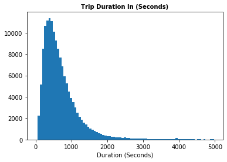

```python
bins = np.arange(0, 5000, 60)
plt.hist(data = df, x = 'duration_sec', bins = bins);
plt.xlabel('Duration (Seconds)');
plt.title("Trip duration in (Seconds)".title(), fontsize = 10, weight = 'bold');
```

### Bivariate Exploration

- **Why this visualization was created?**
- In the bivariate exploration we will be analysing two variables in each plot, so we can see if there is a relationship between the variables we analysed, and to see what the data will reveal to us from relationships between the variables.
- Adding another variable for our exploration (user_type), is there a relationship between the variables?
- which user type uses the bicycle sharing system more often? will it lead to find a key insight for the analysis?

### The relationship between user_type and start_time_hour

- The plot shows that subscribers are most likely to use the system throughout the day, with similarity in usage for both users type (Subscribers & Customers) on 11 p.m., the usage throughout the 24 hours shows little more use to the system from the subscribers user.
- Will it lead to different results of user type usage when exploring the user type with another variable from the data set?

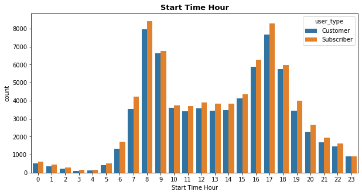

```python
plt.figure(figsize = [10, 5])
sb.countplot(data = df, x = 'start_time_hour', hue = 'user_type');
plt.title('Start Time Hour'.title(), fontsize = 13, weight = 'bold');
plt.xlabel('Start Time Hour');
```

### The relationship between user_type and duration_sec

- The average for both users type (Subscribers & Customers) with higher trip duration for Customers. Customer trip duration 900 seconds (15 min) for subscriber its 700 seconds (11.6 min), the difference is 3.4 min for the customer.
- That is probably because the Subscribers are using it for short trips such as work or school, on the other hand the Customers are using it more for longer trips around the bay area.

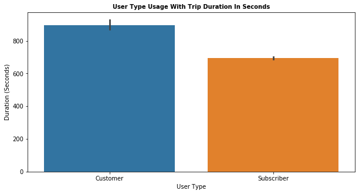

```python
plt.figure(figsize = [10, 5])

sb.barplot(data = df, x = 'user_type', y = 'duration_sec');
plt.title('User Type usage With Trip Duration in Seconds'.title(), fontsize = 10, weight = 'bold');
plt.xlabel('User Type');
plt.ylabel('Duration (Seconds)');
```

### Multivariate Exploration

**Why this visualization was created?**

- Creating a plots of the relationship between user_type, duration_sec, start_time_weekday, and start_time_hour. I see that user_type had the clearest interactions with duration_sec variable. We will explor more when testing three variables toghter in order to get clear image about the user type.
- How clearly does this show up in a multivariate visualization when i add duration_sec variable?

- The plot shows that Subscribers are most likely to use it throughout the weekdays, but on (Sat, Sun, Wed) we can see similarity in usage for both users type (Subscribers & Customers) with little difference for subscribers. lets dig deeper to have clear image about the user type usage.

[figure not shown]

```python
plt.figure(figsize = [12, 5])
start_time_order = ['Mon', 'Tue', 'Wed', 'Thu', 'Fri', 'Sat', 'Sun']

g = sb.countplot(data = df, x = 'start_time_weekday', hue = 'user_type', order = start_time_order);
plt.title('user type usage in start time weekday with trip duration in sec'.title(), fontsize = 14, weight = 'bold');
g.set_xlabel('Start Time Weekday')
g.set_ylabel('Duration (seconds)');
```

### The relationship between user_type, duration_sec and start_time_weekday

- As we can see the average for both users type (Subscribers & Customers) with higher trip duration for Customers in start_time_weekday.
- The results support our findings in (Bivariate Exploration) that probably the Subscribers are using it for short trips such as work or school, and Customers are using it more for longer trips around the bay area, with higher duration of usage for the customers user type in all the days specially on Sat and Sun.
- Does the results apply in a same way with another variable in the data set?

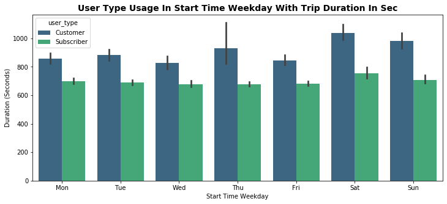

```python
plt.figure(figsize = [12, 5])
start_time_order = ['Mon', 'Tue', 'Wed', 'Thu', 'Fri', 'Sat', 'Sun']

ax = sb.barplot(data = df, x = 'start_time_weekday', y = 'duration_sec', hue = 'user_type',
                  dodge = 0.5, palette = 'viridis', order = start_time_order)

plt.xlabel('Start Time Weekday')
plt.ylabel('Duration (Seconds)')
plt.title("user type usage in start time weekday with trip duration in sec".title(),
         fontsize = 14, weight = 'bold')


plt.show();
```

### The relationship between user_type, duration_sec and start_time_hour

- This prove our findings because even on the start_time_hour (24 hours) customers are more likely to use it with higher trip duration in sec as we can see, which prove that the customers are using the bicycle sharing system more than the subscribers in duration as the plot shows.

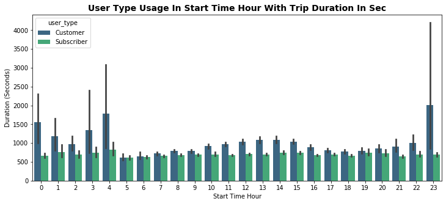

```python
plt.figure(figsize = [12, 5])

ax = sb.barplot(data = df, x = 'start_time_hour', y = 'duration_sec', hue = 'user_type',
                  dodge = 0.5, palette = 'viridis')

plt.xlabel('Start Time Hour')
plt.ylabel('Duration (Seconds)')
plt.title("user type usage in start time hour with trip duration in sec".title(),
         fontsize = 14, weight = 'bold')

plt.show();
```

### Conclusion

- In the bivariate exploration step we saw the the user type shows that subscribers are using more frquently in start_time_hour and in start_time_weekday, when we plotted user type and duration_sec we saw that customers trip duration_sec set to be higher than the subscribers. Which lead s to do further exploration in the multivariate stage, searching for a relationship between user_type, duration_sec, start_time_weekday, and start_time_hour. we saw that user_type had the clearest interactions with duration_sec variable, which we explor more when testing three variables toghter in order to get clear image about the user type, and the results showed us that the average for both users type (Subscribers & Customers) with higher trip duration for Customers in start_time_weekday, even on the start_time_hour customers are more likely to use it with higher trip duration in sec as we can see, which prove that the customers are using the bicycle sharing system more than the subscribers in duration_sec as the plots showed us. That lead us for or key insight that without further exploration we will not reach this results as the some plots showed that the subscribers are using it more on daily and weekly basis but when we added a three varbiables specially duration_sec with user_type against start_time_weekday or start_time_hour we clearly can see that the customer are using it with higher duration in seconds. Customer trip duration 900 seconds (15 min) for subscriber its 700 seconds (11.6 min), the difference is 3.4 min for the customer.

### Limitations

- In the data set we have there is no gender or age columns in our data, that might have help us for our exploration specially in start_time_hour and start_time_weekday so we can know the age of the rider and the gender so it can lead us to do further investigations in or data and find more key insights.

### References

- https://classroom.udacity.com/nanodegrees/nd002/parts/9f7e8991-8bfb-4103-8307-3b6f93f0ecc7/modules/1dc09d28-5703-493c-aab5-a418b8bfa3e1/lessons/495fe81e-ebe8-4d10-a4a2-e85fe01565bd/concepts/469d2cf9-8e2b-42e3-977b-4614caf320d0
- https://classroom.udacity.com/nanodegrees/nd002/parts/9f7e8991-8bfb-4103-8307-3b6f93f0ecc7
- https://knowledge.udacity.com
- https://www.drawingfromdata.com/setting-figure-size-using-seaborn-and-matplotlib